# Data606_HW5

Vijaya Cherukuri

10/02/2019

## 1) HEIGHT OF ADULTS :

### (a) What is the point estimate for the average height of active individuals? What about the median?

#### Ans) Average height is 171.1.

#### Median is 170.3.

### (b) What is the point estimate for the standard deviation of the heights of active individuals? What about the IQR?

#### Ans) SD = 9.4.

```r
(IQR <- 177.8 - 163.8)
```

```
## [1] 14
```

### (c) Is a person who is 1m 80cm (180 cm) tall considered unusually tall? And is a person who is 1m 55cm (155cm) considered unusually short? Explain your reasoning.

#### Ans)

```r
# For 180
x = 180
mu <- 171.1
sigma <- 9.4
(z <- (x - mu)/sigma)
```

```
## [1] 0.9468085
```

```r
# For 155 cm
x = 155
mu <- 171.1
sigma <- 9.4
(z <- (x - mu)/sigma)
```

```
## [1] -1.712766
```

#### z = 0.9468085 i.e less than 2, the person is not unusually tall.

#### z = -1.712766 i.e not beyond -2 the person is not unusually short.

### (d) The researchers take another random sample of physically active individuals. Would you expect the mean and the standard deviation of this new sample to be the ones given above? Explain your reasoning.

#### Ans) Since the new sample would be taken randomly, I would not expect the mean and the standard deviation to be the same as the first sample. Due to the variation in the population, the point estimates for each random sample will be different.

### (e) The sample means obtained are point estimates for the mean height of all active individuals, if the sample of individuals is equivalent to a simple random sample. What measure do we use to quantify the variability of such an estimate . Compute this quantity using the data from the original sample under the condition that the data are a simple random sample.

#### Ans)

```r
sigma  <- 9.4
n <- 507
(variability <- sigma/sqrt(n))
```

```
## [1] 0.4174687
```

## 2) Thanksgiving spending :

### (g) The margin of error is 4.4.

#### Ans)

```r
v1 <- 80.31
v2 <- 89.11
(MARGIN<-(v2 - v1)/2)
```

```
## [1] 4.4
```

#### True. Margin of error is 4.4

## 3) Gifted children -Part I :

### (a) Are conditions for inference satisfied?

#### Ans) Yes,conditions for inference satisfied.Because the sampling was performed randomly, the sample size is over 30,and the distribution is not skewed.

### (b) Suppose you read online that children first count to 10 successfully when they are 32 months old, on average. Perform a hypothesis test to evaluate if these data provide convincing evidence that the average age at which gifted children fist count to 10 successfully is less than the general average of 32 months. Use a significance level of 0.10.

#### Ans)

```r
x <- 32
n <- 36
avg <- 30.69
sd <- 4.31
se <- sd/sqrt(n)
z <- (avg - x)/se
(p <- pnorm(z))
```

```
## [1] 0.0341013
```

### (c) Interpret the p-value in context of the hypothesis test and the data.

#### Ans) If the null hypothesis is true, then the probability of observing a sample mean lower than 30.69 for a sample of 36 children is only 0.0341013 (p-value)..

### (d) Calculate a 90% confidence interval for the average age at which gifted children first count to 10 successfully.

#### Ans)

```r
(v1 <- avg - 1.65 * se)
```

```
## [1] 29.50475
```

```r
(v2 <- avg + 1.65 * se)
```

```
## [1] 31.87525
```

### (e) Do your results from the hypothesis test and the confidence interval agree? Explain.

#### Ans) I am sure that the average age at which gifted children first count to 10 is between 29.5 and 31.9 months.

## 4) Gifted children - Part II :

### (a) Performahypothesistesttoevaluateifthesedataprovideconvincingevidencethattheaverage IQ of mothers of gifted children is different than the average IQ for the population at large, which is 100. Use a significance level of 0.10.

#### Ans)

```r
x <- 100
n <- 36
avg <- 118.2
sd <- 6.5
se <- sd/sqrt(n)
(z = (avg - x)/se)
```

```
## [1] 16.8
```

### (b) Calculate a 90% confidence interval for the average IQ of mothers of gifted children.

#### Ans)

```r
(v1 <- avg - 1.65 * se)
```

```
## [1] 116.4125
```

```r
(v2 <- avg + 1.65 * se)
```

```
## [1] 119.9875
```

### (c) Do your results from the hypothesis test and the confidence interval agree? Explain.

#### Ans) Yes, I was 90% confident that the average IQ of mothers of gifted children is between 116.4125 and 119.9875. This is significantly above population average of 100.

## 5) CLT: Define the term “sampling distribution” of the mean, and describe how the shape, center, and spread of the sampling distribution of the mean change as sample size increases.

#### Ans) A sampling distribution is a probability distribution of a statistic obtained through a large number of samples drawn from a specific population.The sampling distribution of the mean takes the mean of each sample. As the sample size gets larger, the shape becomes on a more ‘normal’ and has a smaller spread.

## 6) CFLBs:

### (a) What is the probability that a randomly chosen light bulb lasts more than 10,500 hours?

#### Ans)

```r
1 - pnorm(q = 10500, mean = 9000, sd = 1000)
```

```
## [1] 0.0668072
```

### (b) Describe the distribution of the mean lifespan of 15 light bulbs.

#### Ans)

```r
(s <- 1000/sqrt(15))
```

```
## [1] 258.1989
```

#### The sample will approximate normal distribution since the population has normal distribution.

#### N(9000, 258.1989)

### (c) What is the probability that the mean lifespan of 15 randomly chosen light bulbs is more than 10,500 hours?

#### Ans)

```r
pnorm(10500, 9000, 1000/sqrt(15), lower.tail = FALSE)
```

```
## [1] 3.133452e-09
```

```r
(Z <- (10500-9000)/258.20)
```

```
## [1] 5.80945
```

### (d) Sketch the two distributions (population and sampling) on the same scale.

#### Ans)

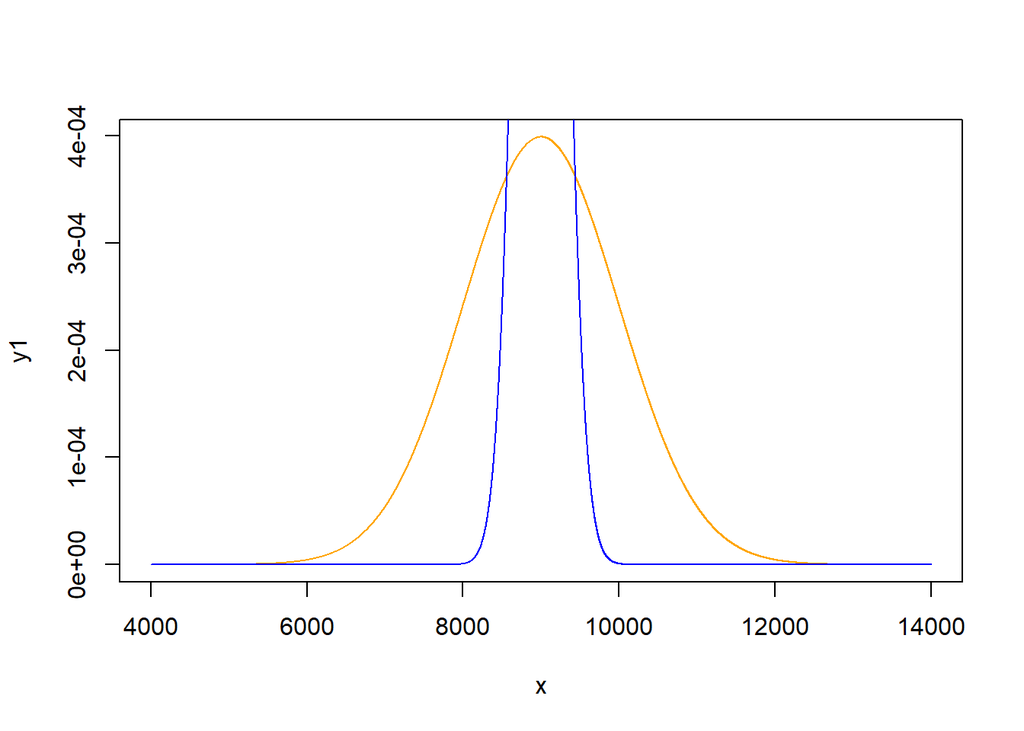

```r
x <- 4000:14000
y1 <- dnorm(x, 9000, 1000)
y2 <- dnorm(x, 9000, 258)
plot(x,y1,type="l",col="orange")
lines(x,y2,col="blue")
```

### (e) Could you estimate the probabilities from parts (a) and (c) if the lifespans of light bulbs had a skewed distribution?

#### Ans) You could not estimate the probabilities for (a) and (c). For part (a), a normal distribution is required to use the Z-score. For part (c), the sample size is too small to represent a normal distribution.

## 7) Same observation, different sample size:

### Suppose you conduct a hypothesis test based on a sample where the sample size is n = 50, and arrive at a p-value of 0.08. You then refer back to your notes and discover that you made a careless mistake, the sample size should have been n = 500. Will your p-value increase, decrease, or stay the same? Explain.

#### Ans) Your p value should decrease. If we assume you plugged 50 into the formula to get the standard error for the sample, changing it to 500 will decrease it by root 10. You will then see the test value differ from the sample by more standard errors, making the p value lower.